# Assignment 3 Part 1: Developing Your Own Classifier

```python
from google.colab import drive
drive.mount("/content/gdrive")
```

## Utilities

We only show the utilities that was not provided in the starter code below.

```python
def summary(net):
    X = torch.rand(size=(1, 3, 227, 227), dtype=torch.float32)
    pipeline = "Model summary"
    print("=" * len(pipeline))
    print(pipeline)
    print("=" * len(pipeline))
    print()

    pipeline = "Feature pipeline"
    print(pipeline)
    print('-' * len(pipeline))
    print()
    for layer in net.features:
        X = layer(X)
        print("{:<15}".format(layer.__class__.__name__), 'output shape: \t', X.shape)

    layer = net.bridge
    X = layer(X)
    print("{:<15}".format(layer.__class__.__name__), 'output shape: \t', X.shape)
    print()

    pipeline = "Classification pipeline"
    print(pipeline)
    print('-' * len(pipeline))
    print()
    for layer in net.classifier:
        X = layer(X)
        print("{:<15}".format(layer.__class__.__name__), 'output shape: \t', X.shape)

    return net
```

# Developing Your Own Model

### Goal

To meet the benchmark for this assignment you will need to improve the network. Note you should have noticed pretrained Alenxt performs really well, but training Alexnet from scratch performs much worse. We hope you can design a better architecture over both the simple classifier and AlexNet to train from scratch.

### How to start

You may take inspiration from other published architectures and architectures discussed in lecture. However, you are NOT allowed to use predefined models (e.g. models from torchvision) or use pretrained weights. Training must be done from scratch with your own custom model.

#### Some hints

There are a variety of different approaches you should try to improve performance from the simple classifier:

- Network architecture changes
  - Number of layers: try adding layers to make your network deeper
  - Batch normalization: adding batch norm between layers will likely give you a significant performance increase
  - Residual connections: as you increase the depth of your network, you will find that having residual connections like those in ResNet architectures will be helpful
- Optimizer: Instead of plain SGD, you may want to add a learning rate schedule, add momentum, or use one of the other optimizers you have learned about like Adam. Check the `torch.optim` package for other optimizers
- Data augmentation: You should use the `torchvision.transforms` module to try adding random resized crops and horizontal flips of the input data. Check `transforms.RandomResizedCrop` and `transforms.RandomHorizontalFlip` for this. Feel free to apply more [transforms](https://pytorch.org/docs/stable/torchvision/transforms.html) for data augmentation which can lead to better performance.
- Epochs: Once you have found a generally good hyperparameter setting try training for more epochs
- Loss function: You might want to add weighting to the `MultiLabelSoftMarginLoss` for classes that are less well represented or experiment with a different loss function

#### Note

We will soon be providing some initial expectations of mAP values as a function of epoch so you can get an early idea whether your implementation works without waiting a long time for training to converge.

### What to submit

Submit your best model to Kaggle and save all plots for the writeup.

## Data augmentation

To better model the data, we augment it by the transformatios shown below, drawing inspiration from [this](https://towardsdatascience.com/improves-cnn-performance-by-applying-data-transformation-bf86b3f4cef4) Medium post . In the color jitter I didn't change the relative concentration of color channels (i.e. saturate or hue) because the `normalize` transformations might need to change if thats the case.

```python
device = torch.device("cuda:0" if torch.cuda.is_available() else "cpu")

normalize = transforms.Normalize(mean=[0.485, 0.456, 0.406],
                                     std= [0.229, 0.224, 0.225])

# Inspired from https://towardsdatascience.com/improves-cnn-performance-by-applying-data-transformation-bf86b3f4cef4
train_transform = transforms.Compose([
            transforms.RandomResizedCrop(227),
            transforms.RandomVerticalFlip(p=0.5),
            transforms.RandomHorizontalFlip(p=0.5),
            transforms.ColorJitter(brightness=0.5, contrast=0.5),
            transforms.ToTensor(),
            normalize
        ])

test_transform = transforms.Compose([
            transforms.Resize(227),
            transforms.CenterCrop(227),
            transforms.ToTensor(),
            normalize,
        ])

ds_train = VocDataset('/content/VOCdevkit_2007/VOC2007/','train',train_transform)
ds_val = VocDataset('/content/VOCdevkit_2007/VOC2007/','val', test_transform)
ds_test = VocDataset('/content/VOCdevkit_2007/VOC2007test/','test', test_transform)
```

```
/content/gdrive/MyDrive/Colab Notebooks/CS498/assignment3_part1/voc_dataloader.py:137: VisibleDeprecationWarning: Creating an ndarray from ragged nested sequences (which is a list-or-tuple of lists-or-tuples-or ndarrays with different lengths or shapes) is deprecated. If you meant to do this, you mu…
  np.array(box_indices),
```

```python
num_epochs = 100
test_frequency = 5
batch_size = 64

train_loader = torch.utils.data.DataLoader(dataset=ds_train,
                                               batch_size=batch_size,
                                               shuffle=True,
                                               num_workers=1)

val_loader = torch.utils.data.DataLoader(dataset=ds_val,
                                               batch_size=batch_size,
                                               shuffle=True,
                                               num_workers=1)

test_loader = torch.utils.data.DataLoader(dataset=ds_test,
                                               batch_size=batch_size,
                                               shuffle=False,
                                               num_workers=1)
```

# Results

## Network structure

All networks shown below consist of three distinct modular parts : the feature extractor, the classifier and a bridge between these two. The feature extractor comprises of CNN architecture. The classifer comprises of fully-connected layers. In all our cases the bridge is just a `flatten()` operation, although in principle, any arbitrary transformations can be applied (an activation for example).

Furthermore, we employ both optimization algorithms (SGD and Adam), but only report results for Adam.

## BaseNet

I recoded the base-network in the structure introduced above. The model summary shows the shape of the outputs as the features get refined.

```python
# TODO: Run your own classifier here
from classifier import MySimpleClassifier
classifier = summary(MySimpleClassifier()).to(device)

criterion = nn.MultiLabelSoftMarginLoss()
# optimizer = torch.optim.SGD(classifier.parameters(), lr=0.01, momentum=0.9)
optimizer = torch.optim.Adam(classifier.parameters(), lr=1e-4)
```

```
=============
Model summary
=============

Feature pipeline
----------------

Conv2d          output shape: 	 torch.Size([1, 64, 223, 223])
ReLU            output shape: 	 torch.Size([1, 64, 223, 223])
MaxPool2d       output shape: 	 torch.Size([1, 64, 111, 111])
Conv2d          output shape: 	 torch.Size([1, 32, 109, 109])
ReLU            output shape: 	 torch.Size([1, 32, 109, 109])
MaxPool2d       output shape: 	 torch.Size([1, 32, 54, 54])
Conv2d          output shape: 	 torch.Size([1, 16, 52, 52])
ReLU            output shape: 	 torch.Size([1, 16, 52, 52])
MaxPool2d       output shape: 	 torch.Size([1, 16, 26, 26])
Flatten         output shape: 	 torch.Size([1, 10816])

Classification pipeline
-----------------------

Linear          output shape: 	 torch.Size([1, 120])
ReLU            output shape: 	 torch.Size([1, 120])
Linear          output shape: 	 torch.Size([1, 84])
ReLU            output shape: 	 torch.Size([1, 84])
Linear          output shape: 	 torch.Size([1, 21])
```

We train the model now, but skip the output for brevity.

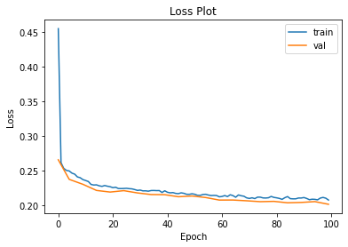

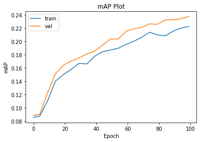

```python
plot_losses(train_losses, val_losses, test_frequency, num_epochs)
plot_mAP(train_mAPs, val_mAPs, test_frequency, num_epochs)
```

```python
mAP_test, test_loss, test_aps = test_classifier(test_loader, classifier, criterion)
print(mAP_test)
```

```
-------  Class: aeroplane        AP:   0.4892  -------
-------  Class: bicycle          AP:   0.1790  -------
-------  Class: bird             AP:   0.1666  -------
-------  Class: boat             AP:   0.2410  -------
-------  Class: bottle           AP:   0.0960  -------
-------  Class: bus              AP:   0.1145  -------
-------  Class: car              AP:   0.4374  -------
-------  Class: cat              AP:   0.1615  -------
-------  Class: chair            AP:   0.2778  -------
-------  Class: cow              AP:   0.0650  -------
-------  Class: diningtable      AP:   0.1998  -------
-------  Class: dog              AP:   0.1820  -------
-------  Class: horse            AP:   0.3819  -------
-------  Class: motorbike        AP:   0.1653  -------
-------  Class: person           AP:   0.6318  -------
-------  Class: pottedplant      AP:   0.1486  -------
-------  Class: sheep            AP:   0.1342  -------
-------  Class: sofa             AP:   0.2043  -------
-------  Class: train            AP:   0.2464  -------
-------  Class: tvmonitor        AP:   0.1591  -------
mAP: 0.2341
Avg loss: 0.1972078081124868
0.23406144366922071
```

## Version 1

```python
# TODO: Run your own classifier here
from classifier import MyClassifierV1
classifier = summary(MyClassifierV1()).to(device)

criterion = nn.MultiLabelSoftMarginLoss()
# optimizer = torch.optim.SGD(classifier.parameters(), lr=0.01, momentum=0.9)
optimizer = torch.optim.Adam(classifier.parameters(), lr=1e-4)
```

```
=============
Model summary
=============

Feature pipeline
----------------

Conv2d          output shape: 	 torch.Size([1, 64, 225, 225])
ReLU            output shape: 	 torch.Size([1, 64, 225, 225])
MaxPool2d       output shape: 	 torch.Size([1, 64, 112, 112])
Conv2d          output shape: 	 torch.Size([1, 128, 110, 110])
ReLU            output shape: 	 torch.Size([1, 128, 110, 110])
MaxPool2d       output shape: 	 torch.Size([1, 128, 55, 55])
Conv2d          output shape: 	 torch.Size([1, 256, 53, 53])
ReLU            output shape: 	 torch.Size([1, 256, 53, 53])
MaxPool2d       output shape: 	 torch.Size([1, 256, 26, 26])
Conv2d          output shape: 	 torch.Size([1, 16, 26, 26])
ReLU            output shape: 	 torch.Size([1, 16, 26, 26])
Flatten         output shape: 	 torch.Size([1, 10816])

Classification pipeline
-----------------------

Linear          output shape: 	 torch.Size([1, 120])
ReLU            output shape: 	 torch.Size([1, 120])
Linear          output shape: 	 torch.Size([1, 84])
ReLU            output shape: 	 torch.Size([1, 84])
Linear          output shape: 	 torch.Size([1, 21])
```

We train the model now, but skip the output for brevity.

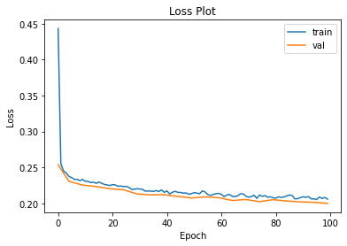

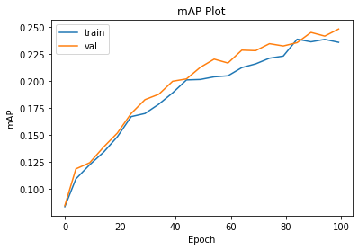

```python
plot_losses(train_losses, val_losses, test_frequency, num_epochs)
plot_mAP(train_mAPs, val_mAPs, test_frequency, num_epochs)
```

```python
mAP_test, test_loss, test_aps = test_classifier(test_loader, classifier, criterion)
print(mAP_test)
```

```
-------  Class: aeroplane        AP:   0.5468  -------
-------  Class: bicycle          AP:   0.1246  -------
-------  Class: bird             AP:   0.1410  -------
-------  Class: boat             AP:   0.2299  -------
-------  Class: bottle           AP:   0.1252  -------
-------  Class: bus              AP:   0.1299  -------
-------  Class: car              AP:   0.5092  -------
-------  Class: cat              AP:   0.1849  -------
-------  Class: chair            AP:   0.3045  -------
-------  Class: cow              AP:   0.1214  -------
-------  Class: diningtable      AP:   0.2356  -------
-------  Class: dog              AP:   0.1817  -------
-------  Class: horse            AP:   0.3675  -------
-------  Class: motorbike        AP:   0.1424  -------
-------  Class: person           AP:   0.6246  -------
-------  Class: pottedplant      AP:   0.1285  -------
-------  Class: sheep            AP:   0.1509  -------
-------  Class: sofa             AP:   0.2001  -------
-------  Class: train            AP:   0.2501  -------
-------  Class: tvmonitor        AP:   0.1584  -------
mAP: 0.2429
Avg loss: 0.19605243779145753
0.24286326107854542
```

## Version 2

We only see a marginal improvement in Version 1. One possible reason is that the network has enough representational power, but cannot effectively learn because of vanishing ReLU gradients in the deep convolutional layers.

From Version 1, then we make one change.

- Inspired by **GoogleNet (Inception v3)**, add BatchNorm layers after the convolution, but before the ReLU. The idea is to make at least one part of the network effectively learn.

```python
# TODO: Run your own classifier here
from classifier import MyClassifierV2
classifier = summary(MyClassifierV2()).to(device)

criterion = nn.MultiLabelSoftMarginLoss()
# optimizer = torch.optim.SGD(classifier.parameters(), lr=0.01, momentum=0.9)
optimizer = torch.optim.Adam(classifier.parameters(), lr=1e-4)
```

```
=============
Model summary
=============

Feature pipeline
----------------

Conv2d          output shape: 	 torch.Size([1, 64, 225, 225])
BatchNorm2d     output shape: 	 torch.Size([1, 64, 225, 225])
ReLU            output shape: 	 torch.Size([1, 64, 225, 225])
MaxPool2d       output shape: 	 torch.Size([1, 64, 112, 112])
Conv2d          output shape: 	 torch.Size([1, 128, 110, 110])
BatchNorm2d     output shape: 	 torch.Size([1, 128, 110, 110])
ReLU            output shape: 	 torch.Size([1, 128, 110, 110])
MaxPool2d       output shape: 	 torch.Size([1, 128, 55, 55])
Conv2d          output shape: 	 torch.Size([1, 256, 53, 53])
BatchNorm2d     output shape: 	 torch.Size([1, 256, 53, 53])
ReLU            output shape: 	 torch.Size([1, 256, 53, 53])
MaxPool2d       output shape: 	 torch.Size([1, 256, 26, 26])
Conv2d          output shape: 	 torch.Size([1, 16, 26, 26])
BatchNorm2d     output shape: 	 torch.Size([1, 16, 26, 26])
ReLU            output shape: 	 torch.Size([1, 16, 26, 26])
Flatten         output shape: 	 torch.Size([1, 10816])

Classification pipeline
-----------------------

Linear          output shape: 	 torch.Size([1, 120])
ReLU            output shape: 	 torch.Size([1, 120])
Linear          output shape: 	 torch.Size([1, 84])
ReLU            output shape: 	 torch.Size([1, 84])
Linear          output shape: 	 torch.Size([1, 21])
```

We train the model now, but skip the output for brevity.

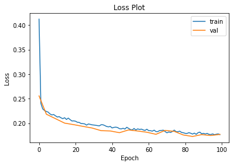

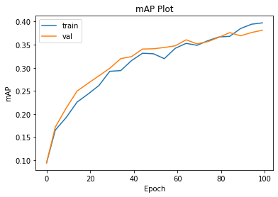

```python
plot_losses(train_losses, val_losses, test_frequency, num_epochs)
plot_mAP(train_mAPs, val_mAPs, test_frequency, num_epochs)
```

```python
mAP_test, test_loss, test_aps = test_classifier(test_loader, classifier, criterion)
print(mAP_test)
```

```
-------  Class: aeroplane        AP:   0.6109  -------
-------  Class: bicycle          AP:   0.3184  -------
-------  Class: bird             AP:   0.2947  -------
-------  Class: boat             AP:   0.4780  -------
-------  Class: bottle           AP:   0.1520  -------
-------  Class: bus              AP:   0.2102  -------
-------  Class: car              AP:   0.6312  -------
-------  Class: cat              AP:   0.3878  -------
-------  Class: chair            AP:   0.4512  -------
-------  Class: cow              AP:   0.1388  -------
-------  Class: diningtable      AP:   0.3303  -------
-------  Class: dog              AP:   0.2949  -------
-------  Class: horse            AP:   0.6287  -------
-------  Class: motorbike        AP:   0.4230  -------
-------  Class: person           AP:   0.7716  -------
-------  Class: pottedplant      AP:   0.2160  -------
-------  Class: sheep            AP:   0.1971  -------
-------  Class: sofa             AP:   0.2499  -------
-------  Class: train            AP:   0.4718  -------
-------  Class: tvmonitor        AP:   0.3251  -------
mAP: 0.3791
Avg loss: 0.17405455463971847
0.37907929926777223
```

## Version 3

We see a good improvement in mAP for Version 2. But here, there may be a chance to further improve generalization and learning. The reduction of 256 channels to 16 channels in the last layer using 1x1 convolutions seems aggressive---the classifier might be getting data that is too correlated.

To prevent this, we

- Use 1x1 convolutions to reduce 256 channels to 128 channels. To accommodate these additional degrees of freedom, we make the classifier more bulky by adding width to the linear layers. This has its roots in **AlexNet**, where the MLP is very wide. Here we choose to make the 128 x 26 x 26 = 86528 outputs map onto a 1024 wide MLP, which in turn maps onto a 420 layer MLP which then maps to 21 scores. The numbers were chosen based on the same the ratio of neurons between MLP as Version 2.

```python
# TODO: Run your own classifier here
from classifier import MyClassifierV3
classifier = summary(MyClassifierV3()).to(device)

criterion = nn.MultiLabelSoftMarginLoss()
# optimizer = torch.optim.SGD(classifier.parameters(), lr=0.01, momentum=0.9)
optimizer = torch.optim.Adam(classifier.parameters(), lr=1e-4)
```

```
=============
Model summary
=============

Feature pipeline
----------------

Conv2d          output shape: 	 torch.Size([1, 64, 225, 225])
BatchNorm2d     output shape: 	 torch.Size([1, 64, 225, 225])
ReLU            output shape: 	 torch.Size([1, 64, 225, 225])
MaxPool2d       output shape: 	 torch.Size([1, 64, 112, 112])
Conv2d          output shape: 	 torch.Size([1, 128, 110, 110])
BatchNorm2d     output shape: 	 torch.Size([1, 128, 110, 110])
ReLU            output shape: 	 torch.Size([1, 128, 110, 110])
MaxPool2d       output shape: 	 torch.Size([1, 128, 55, 55])
Conv2d          output shape: 	 torch.Size([1, 256, 53, 53])
BatchNorm2d     output shape: 	 torch.Size([1, 256, 53, 53])
ReLU            output shape: 	 torch.Size([1, 256, 53, 53])
MaxPool2d       output shape: 	 torch.Size([1, 256, 26, 26])
Conv2d          output shape: 	 torch.Size([1, 128, 26, 26])
BatchNorm2d     output shape: 	 torch.Size([1, 128, 26, 26])
ReLU            output shape: 	 torch.Size([1, 128, 26, 26])
Flatten         output shape: 	 torch.Size([1, 86528])

Classification pipeline
-----------------------

Linear          output shape: 	 torch.Size([1, 1024])
ReLU            output shape: 	 torch.Size([1, 1024])
Linear          output shape: 	 torch.Size([1, 420])
ReLU            output shape: 	 torch.Size([1, 420])
Linear          output shape: 	 torch.Size([1, 21])
```

We train the model now, but skip the output for brevity.

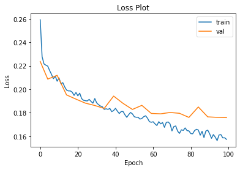

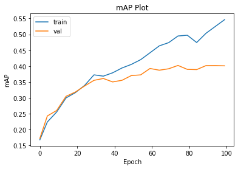

```python
plot_losses(train_losses, val_losses, test_frequency, num_epochs)
plot_mAP(train_mAPs, val_mAPs, test_frequency, num_epochs)
```

```python
mAP_test, test_loss, test_aps = test_classifier(test_loader, classifier, criterion)
print(mAP_test)
```

```
-------  Class: aeroplane        AP:   0.6402  -------
-------  Class: bicycle          AP:   0.3640  -------
-------  Class: bird             AP:   0.3149  -------
-------  Class: boat             AP:   0.4166  -------
-------  Class: bottle           AP:   0.1608  -------
-------  Class: bus              AP:   0.2968  -------
-------  Class: car              AP:   0.6404  -------
-------  Class: cat              AP:   0.4089  -------
-------  Class: chair            AP:   0.4546  -------
-------  Class: cow              AP:   0.1555  -------
-------  Class: diningtable      AP:   0.3140  -------
-------  Class: dog              AP:   0.3080  -------
-------  Class: horse            AP:   0.6851  -------
-------  Class: motorbike        AP:   0.4251  -------
-------  Class: person           AP:   0.7877  -------
-------  Class: pottedplant      AP:   0.2226  -------
-------  Class: sheep            AP:   0.2907  -------
-------  Class: sofa             AP:   0.2416  -------
-------  Class: train            AP:   0.5983  -------
-------  Class: tvmonitor        AP:   0.3856  -------
mAP: 0.4056
Avg loss: 0.17225009069228783
0.40556255974498817
```

## Version 4

We see a marginal improvement in mAP for Version 3. However what is more concerning is that the generalization decreases, as evident from the growing gap between training and validation losses. The probable reason is that by increasing the width of the linear layers, we have added too many degrees of freedom and the network starts overfitting. Additionally, these degrees of freedom imply that we need to train the network for longer duration.

While there are several ways to prevent overfitting in the classification layers (dropout, L2 loss regularization), we also need means to reduce the degrees of freedom. We achieve this by

- Retaining the classifeir structure from V3 (for its generalization capabilites), but adding an average pooling layer, inspired by **GoogleNet (Inception v3)** and **NiN** ,at the end of the feature extractor. The average pooling size is 5x5 to roughly recover the degrees of freedom as the V2 architecture.

```python
# TODO: Run your own classifier here
from classifier import MyClassifierV4
classifier = summary(MyClassifierV4()).to(device)

criterion = nn.MultiLabelSoftMarginLoss()
# optimizer = torch.optim.SGD(classifier.parameters(), lr=0.01, momentum=0.9)
optimizer = torch.optim.Adam(classifier.parameters(), lr=1e-4)
```

```
=============
Model summary
=============

Feature pipeline
----------------

Conv2d          output shape: 	 torch.Size([1, 64, 225, 225])
BatchNorm2d     output shape: 	 torch.Size([1, 64, 225, 225])
ReLU            output shape: 	 torch.Size([1, 64, 225, 225])
MaxPool2d       output shape: 	 torch.Size([1, 64, 112, 112])
Conv2d          output shape: 	 torch.Size([1, 128, 110, 110])
BatchNorm2d     output shape: 	 torch.Size([1, 128, 110, 110])
ReLU            output shape: 	 torch.Size([1, 128, 110, 110])
MaxPool2d       output shape: 	 torch.Size([1, 128, 55, 55])
Conv2d          output shape: 	 torch.Size([1, 256, 53, 53])
BatchNorm2d     output shape: 	 torch.Size([1, 256, 53, 53])
ReLU            output shape: 	 torch.Size([1, 256, 53, 53])
MaxPool2d       output shape: 	 torch.Size([1, 256, 26, 26])
Conv2d          output shape: 	 torch.Size([1, 128, 26, 26])
BatchNorm2d     output shape: 	 torch.Size([1, 128, 26, 26])
ReLU            output shape: 	 torch.Size([1, 128, 26, 26])
AdaptiveAvgPool2d output shape: 	 torch.Size([1, 128, 5, 5])
Flatten         output shape: 	 torch.Size([1, 3200])

Classification pipeline
-----------------------

Linear          output shape: 	 torch.Size([1, 1024])
ReLU            output shape: 	 torch.Size([1, 1024])
Linear          output shape: 	 torch.Size([1, 420])
ReLU            output shape: 	 torch.Size([1, 420])
Linear          output shape: 	 torch.Size([1, 21])
```

We train the model now, but skip the output for brevity.

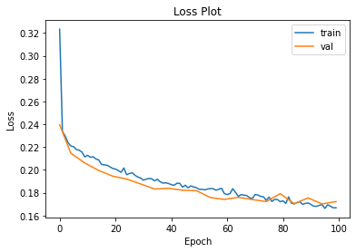

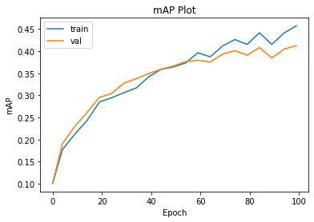

```python
plot_losses(train_losses, val_losses, test_frequency, num_epochs)
plot_mAP(train_mAPs, val_mAPs, test_frequency, num_epochs)
```

```python
mAP_test, test_loss, test_aps = test_classifier(test_loader, classifier, criterion)
print(mAP_test)
```

```
-------  Class: aeroplane        AP:   0.6271  -------
-------  Class: bicycle          AP:   0.3652  -------
-------  Class: bird             AP:   0.3485  -------
-------  Class: boat             AP:   0.4848  -------
-------  Class: bottle           AP:   0.1596  -------
-------  Class: bus              AP:   0.2684  -------
-------  Class: car              AP:   0.6464  -------
-------  Class: cat              AP:   0.4140  -------
-------  Class: chair            AP:   0.4764  -------
-------  Class: cow              AP:   0.1873  -------
-------  Class: diningtable      AP:   0.3399  -------
-------  Class: dog              AP:   0.3250  -------
-------  Class: horse            AP:   0.6523  -------
-------  Class: motorbike        AP:   0.4536  -------
-------  Class: person           AP:   0.7936  -------
-------  Class: pottedplant      AP:   0.2404  -------
-------  Class: sheep            AP:   0.2149  -------
-------  Class: sofa             AP:   0.2861  -------
-------  Class: train            AP:   0.6113  -------
-------  Class: tvmonitor        AP:   0.3568  -------
mAP: 0.4126
Avg loss: 0.16924830277760824
0.4125743087131082
```

## Version 5

We once again see a marginal improvement in mAP for Version 4. The network also seems to perform favorably (i.e. both training and validation loss decrease together).

To test the effects of potential overfitting in the classification layers, we now

- Add Dropout in the MLP inspired by **AlexNet**

```python
# TODO: Run your own classifier here
from classifier import MyClassifierV5
classifier = summary(MyClassifierV5()).to(device)

criterion = nn.MultiLabelSoftMarginLoss()
# optimizer = torch.optim.SGD(classifier.parameters(), lr=0.01, momentum=0.9)
optimizer = torch.optim.Adam(classifier.parameters(), lr=1e-4)
```

```
=============
Model summary
=============

Feature pipeline
----------------

Conv2d          output shape: 	 torch.Size([1, 64, 225, 225])
BatchNorm2d     output shape: 	 torch.Size([1, 64, 225, 225])
ReLU            output shape: 	 torch.Size([1, 64, 225, 225])
MaxPool2d       output shape: 	 torch.Size([1, 64, 112, 112])
Conv2d          output shape: 	 torch.Size([1, 128, 110, 110])
BatchNorm2d     output shape: 	 torch.Size([1, 128, 110, 110])
ReLU            output shape: 	 torch.Size([1, 128, 110, 110])
MaxPool2d       output shape: 	 torch.Size([1, 128, 55, 55])
Conv2d          output shape: 	 torch.Size([1, 256, 53, 53])
BatchNorm2d     output shape: 	 torch.Size([1, 256, 53, 53])
ReLU            output shape: 	 torch.Size([1, 256, 53, 53])
MaxPool2d       output shape: 	 torch.Size([1, 256, 26, 26])
Conv2d          output shape: 	 torch.Size([1, 128, 26, 26])
BatchNorm2d     output shape: 	 torch.Size([1, 128, 26, 26])
ReLU            output shape: 	 torch.Size([1, 128, 26, 26])
AdaptiveAvgPool2d output shape: 	 torch.Size([1, 128, 5, 5])
Flatten         output shape: 	 torch.Size([1, 3200])

Classification pipeline
-----------------------

Linear          output shape: 	 torch.Size([1, 1024])
ReLU            output shape: 	 torch.Size([1, 1024])
Dropout         output shape: 	 torch.Size([1, 1024])
Linear          output shape: 	 torch.Size([1, 420])
ReLU            output shape: 	 torch.Size([1, 420])
Dropout         output shape: 	 torch.Size([1, 420])
Linear          output shape: 	 torch.Size([1, 21])
```

We train the model now, but skip the output for brevity.

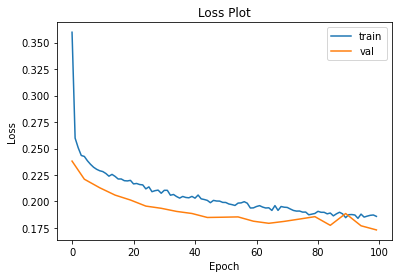

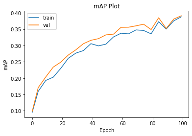

```python
plot_losses(train_losses, val_losses, test_frequency, num_epochs)
plot_mAP(train_mAPs, val_mAPs, test_frequency, num_epochs)
```

```python
mAP_test, test_loss, test_aps = test_classifier(test_loader, classifier, criterion)
print(mAP_test)
```

```
-------  Class: aeroplane        AP:   0.6041  -------
-------  Class: bicycle          AP:   0.3158  -------
-------  Class: bird             AP:   0.3070  -------
-------  Class: boat             AP:   0.4555  -------
-------  Class: bottle           AP:   0.1804  -------
-------  Class: bus              AP:   0.2367  -------
-------  Class: car              AP:   0.6214  -------
-------  Class: cat              AP:   0.4041  -------
-------  Class: chair            AP:   0.4608  -------
-------  Class: cow              AP:   0.1542  -------
-------  Class: diningtable      AP:   0.3080  -------
-------  Class: dog              AP:   0.3003  -------
-------  Class: horse            AP:   0.6438  -------
-------  Class: motorbike        AP:   0.3886  -------
-------  Class: person           AP:   0.7667  -------
-------  Class: pottedplant      AP:   0.2337  -------
-------  Class: sheep            AP:   0.2165  -------
-------  Class: sofa             AP:   0.2474  -------
-------  Class: train            AP:   0.5016  -------
-------  Class: tvmonitor        AP:   0.3841  -------
mAP: 0.3865
Avg loss: 0.17029416312774023
0.3865239291198798
```

Finally, we pick the best model among all (v4) and report it in Kaggle.